# Plant Growth Project

## Introduction

With this data set I am trying to find the most important set of variables to controll for consistent plant growth. I would assume that it would include fertilizer and soil type. I will read in the data, assess normality, create visuals of the data to better assess it, and run many correlation matrices to narrow down variables of importance.

[Here](https://www.kaggle.com/datasets/gorororororo23/plant-growth-data-classification/data) is the link to the data set!

```python
import warnings
warnings.filterwarnings('ignore')
warnings.filterwarnings('ignore', category=FutureWarning)
warnings.filterwarnings('ignore', category=DeprecationWarning)  # Add this if you have deprecation warnings
import pandas as pd
import matplotlib.pyplot as plt
from scipy import stats
import seaborn as sns


plant_data = pd.read_csv('plant_growth_data.csv')
```

```python
plant_data.head()
```

|  | Soil_Type | Sunlight_Hours | Water_Frequency | Fertilizer_Type | Temperature | Humidity | Growth_Milestone |
| --- | --- | --- | --- | --- | --- | --- | --- |
| 0 | loam | 5.192294 | bi-weekly | chemical | 31.719602 | 61.591861 | 0 |
| 1 | sandy | 4.033133 | weekly | organic | 28.919484 | 52.422276 | 1 |
| 2 | loam | 8.892769 | bi-weekly | none | 23.179059 | 44.660539 | 0 |
| 3 | loam | 8.241144 | bi-weekly | none | 18.465886 | 46.433227 | 0 |
| 4 | sandy | 8.374043 | bi-weekly | organic | 18.128741 | 63.625923 | 0 |

# Describing The Data Set

Soil_Type: The type or composition of soil in which the plants are grown.

Sunlight_Hours: The duration or intensity of sunlight exposure received by the plants.

Water_Frequency: How often the plants are watered, indicating the watering schedule.

Fertilizer_Type: The type of fertilizer used for nourishing the plants.

Temperature: The ambient temperature conditions under which the plants are grown.

Humidity: The level of moisture or humidity in the environment surrounding the plants.

Growth_Milestone: Descriptions or markers indicating stages or significant events in the growth process of the plants.

```python
true_false_counts = plant_data.isnull().sum()

print(true_false_counts)
```

```
Soil_Type           0
Sunlight_Hours      0
Water_Frequency     0
Fertilizer_Type     0
Temperature         0
Humidity            0
Growth_Milestone    0
dtype: int64
```

There were 0 null values in this data set!

# Accessing Normal Distribution

```
array([[<Axes: title={'center': 'Sunlight_Hours'}>,
        <Axes: title={'center': 'Temperature'}>],
       [<Axes: title={'center': 'Humidity'}>,
        <Axes: title={'center': 'Growth_Milestone'}>]], dtype=object)
```

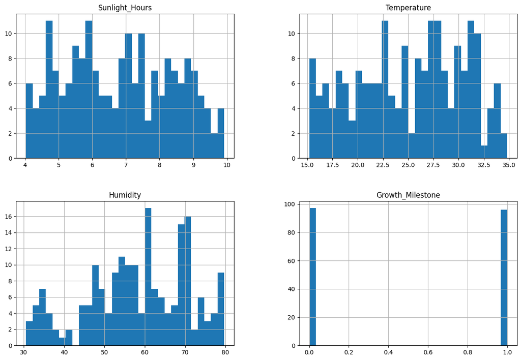

```python
plant_data.hist(bins=30, figsize=(15, 10))
```

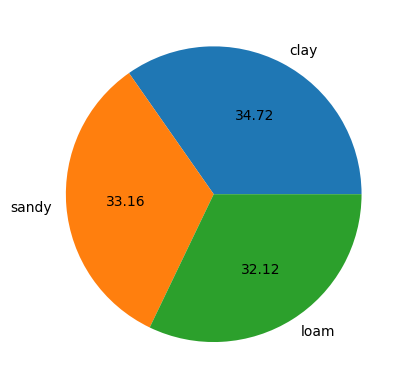

```python
plant_data['Soil_Type'].value_counts().plot(kind = 'pie', autopct = '%.2f')
plt.ylabel(None)
```

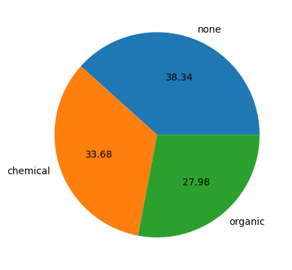

```python
plant_data['Fertilizer_Type'].value_counts().plot(kind = 'pie', autopct = '%.2f')
plt.ylabel(None)
```

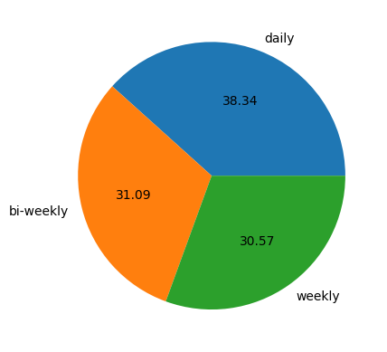

```python
plant_data['Water_Frequency'].value_counts().plot(kind = 'pie', autopct = '%.2f')
plt.ylabel(None)
```

# Visualizations

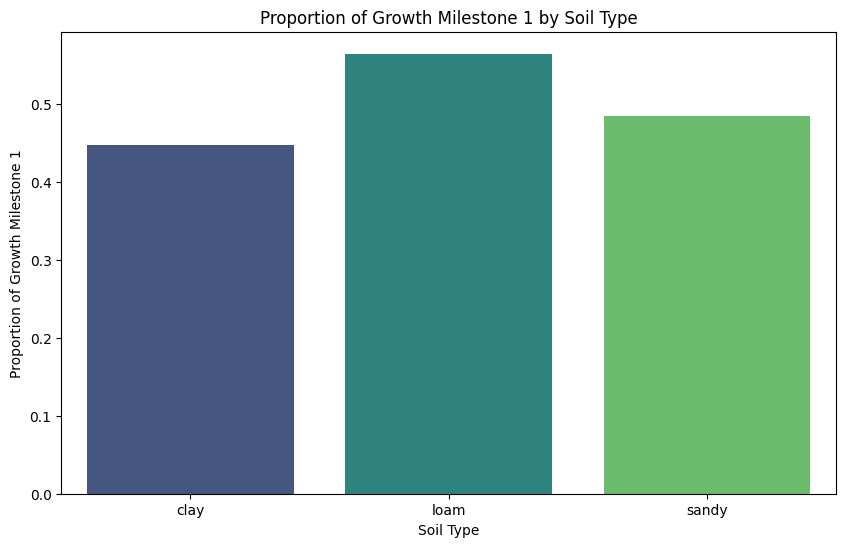

```python
Soil_proportions = plant_data.groupby('Soil_Type')['Growth_Milestone'].mean().reset_index()


plt.figure(figsize=(10, 6))
sns.barplot(x='Soil_Type', y='Growth_Milestone', data=Soil_proportions, palette='viridis')
plt.title('Proportion of Growth Milestone 1 by Soil Type')
plt.xlabel('Soil Type')
plt.ylabel('Proportion of Growth Milestone 1')
plt.show()
```

It doesn’t really matter what soil type you have the plant in; they all have about a 50% success rate. It is obvious that there are more important factors in play than soil type. It could be that different humidity levels work better with different soils. Also, it would depend on the climate, drainage level, heat, and plant type. There are many factors that go into growing a plant. I can attempt to find the perfect combination for this specific type of plant."

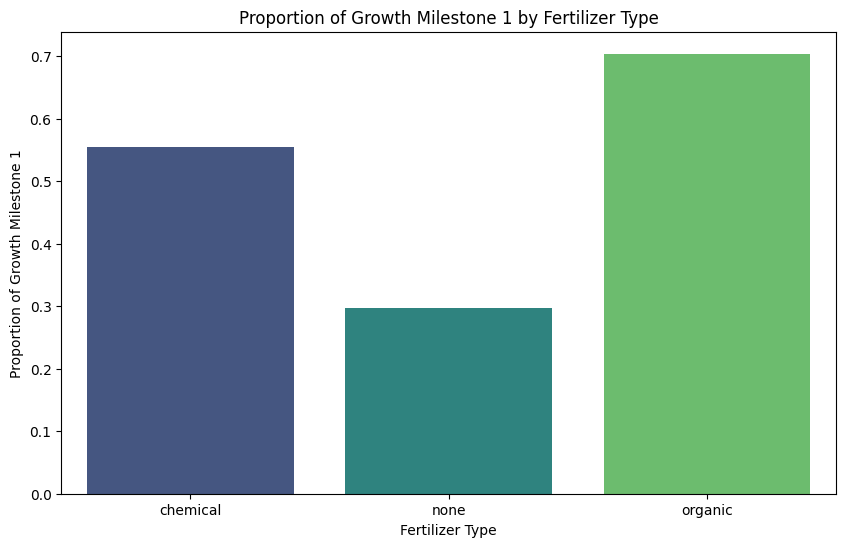

```python
fertilizer_proportions = plant_data.groupby('Fertilizer_Type')['Growth_Milestone'].mean().reset_index()


plt.figure(figsize=(10, 6))
sns.barplot(x='Fertilizer_Type', y='Growth_Milestone', data=fertilizer_proportions, palette='viridis')
plt.title('Proportion of Growth Milestone 1 by Fertilizer Type')
plt.xlabel('Fertilizer Type')
plt.ylabel('Proportion of Growth Milestone 1')
plt.show()
```

From this we can see that overall organic fertilizer is the best option. But more notably, not using any type of fertilizer is a fatal error if plant growth consistency is a goal.

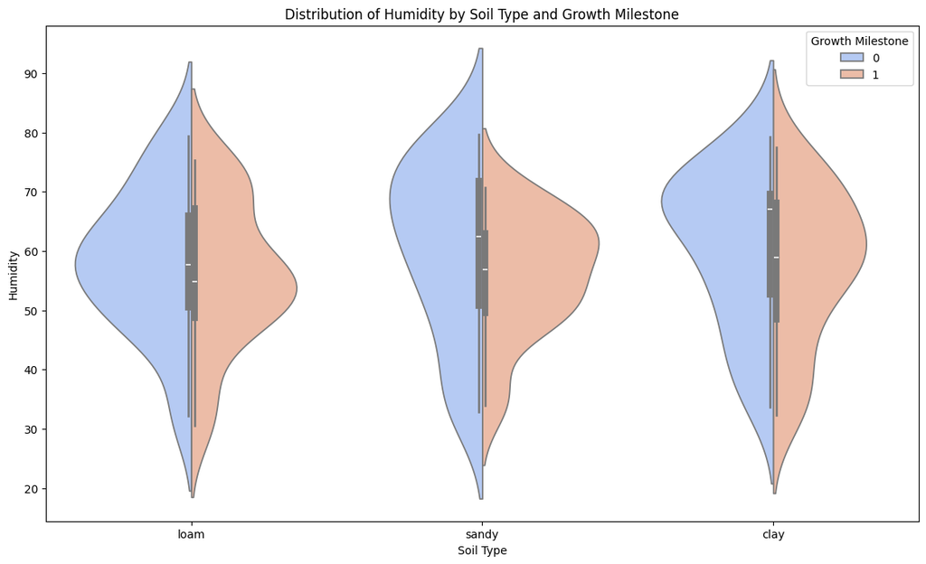

```python
plt.figure(figsize=(14, 8))
sns.violinplot(x='Soil_Type', y='Humidity', hue='Growth_Milestone', data=plant_data, split=True, palette='coolwarm')
plt.title('Distribution of Humidity by Soil Type and Growth Milestone')
plt.xlabel('Soil Type')
plt.ylabel('Humidity')
plt.legend(title='Growth Milestone')
plt.show()
```

This violin plot show us that each soil type does have a preffered humidity type. Loam soil reacts best to humidity being around 55%. Sandy soil does best around 55%, and clay does best at a higher humidity, closer to 60-65%.

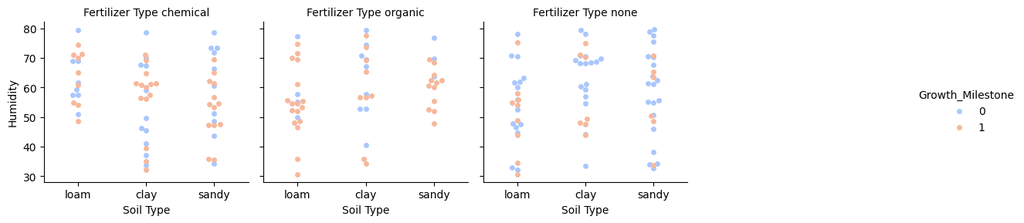

```python
g = sns.FacetGrid(plant_data, col='Fertilizer_Type', hue='Growth_Milestone', palette='coolwarm', col_wrap=4)
g.map(sns.swarmplot, 'Soil_Type', 'Humidity', dodge=True)
g.add_legend()
g.set_axis_labels('Soil Type', 'Humidity')
g.set_titles(col_template="Fertilizer Type {col_name}")
plt.show()
```

Further extrapolating on humidity and soil type I wanted to add the fertilizer variable to the analysis. This is showing that certain Fertilizer types work best with different soil types, and we can still see groupings at what seem to be the best humidity levels.

# Best soils and humidity levels for each fertilizer type

## Chemical Fertilizer

Clay soil at 55-60% humidity was the most successful

## Organic Fertilizer

Sandy soil had the least number of failures using organic fertilizer, this would be my recommendation, when kept below 70% humidity especially there were very few failed plants. Loam soil type was also very successful at a humidity level from 45-55%.

## No Fertilizer

Loam was the soil type which has the most success for this fertilizer type, however, generally using no fertilizer meant the plants had a bad chance at reaching their growth milestone. Notably clay soil type was the worst, which a large grouping of failed plants at 70% humidity.

**Mapping variables

*Key

Water_Frequency -daily = 1 -weekly = 2 -bi-weekly = 3

Soil_Type -loam = 1 -sandy = 2 -clay = 3

Fertilizer_Type -none = 0 -organic = 1 -chemical = 2

I need variables to be numerical instead of strings to make it easier to do analysis with, by mapping these strings to 1s, 2s, and 3s I will be able to run correlation tests to see which variables I should be loooking at.

```python
mapping = {
    'daily' : 1,
    'weekly' : 2,
    'bi-weekly' : 3

}

mapping2 = {
    'loam' : 1,
    'sandy' : 2,
    'clay' : 3
}

mapping3 = {
    'none' : 0,
    'organic' : 1,
    'chemical' : 2
}

plant_data['Water_Frequency'] = plant_data['Water_Frequency'].map(mapping)
plant_data['Soil_Type'] = plant_data['Soil_Type'].map(mapping2)
plant_data['Fertilizer_Type'] = plant_data['Fertilizer_Type'].map(mapping3)
plant_data
```

|  | Soil_Type | Sunlight_Hours | Water_Frequency | Fertilizer_Type | Temperature | Humidity | Growth_Milestone |
| --- | --- | --- | --- | --- | --- | --- | --- |
| 0 | 1 | 5.192294 | 3 | 2 | 31.719602 | 61.591861 | 0 |
| 1 | 2 | 4.033133 | 2 | 1 | 28.919484 | 52.422276 | 1 |
| 2 | 1 | 8.892769 | 3 | 0 | 23.179059 | 44.660539 | 0 |
| 3 | 1 | 8.241144 | 3 | 0 | 18.465886 | 46.433227 | 0 |
| 4 | 2 | 8.374043 | 3 | 1 | 18.128741 | 63.625923 | 0 |
| ... | ... | ... | ... | ... | ... | ... | ... |
| 188 | 2 | 5.652000 | 1 | 0 | 28.000000 | 70.200000 | 0 |
| 189 | 3 | 7.528000 | 2 | 2 | 30.500000 | 60.100000 | 1 |
| 190 | 1 | 4.934000 | 3 | 0 | 24.500000 | 61.700000 | 0 |
| 191 | 2 | 8.273000 | 1 | 1 | 27.900000 | 69.500000 | 1 |
| 192 | 3 | 6.732000 | 2 | 0 | 21.700000 | 56.900000 | 0 |

193 rows × 7 columns

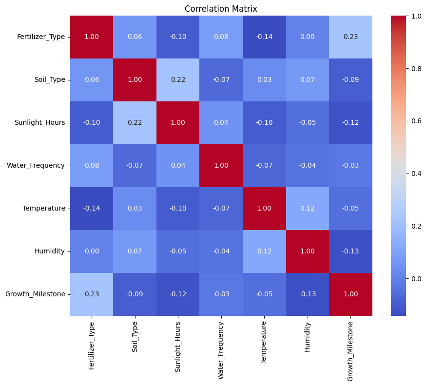

```python
plt.figure(figsize=(10, 8))
corr = plant_data[['Fertilizer_Type','Soil_Type','Sunlight_Hours', 'Water_Frequency', 'Temperature', 'Humidity', 'Growth_Milestone']].corr()
sns.heatmap(corr, annot=True, cmap='coolwarm', fmt='.2f')
plt.title('Correlation Matrix')
plt.show()
```

I was perplexed to see that soil type had such a low corelation value, this explain why, it dosent really matter what soil type you have the plant in, they all preform fairly well, it is obvious that there are more important factors in play than the soil type. it could be that different humidity types work better with differnt soils, also it would depend on the climate, drainage level, heat, plant type. There are many factors that go into growing a plant. I can attempt to find the perfect combination for this specific type of plant

```python
df_1 = plant_data[plant_data['Growth_Milestone'] == 1]
```

[figure not shown]

```python
sns.scatterplot(data=plant_data, x='Sunlight_Hours', y='Humidity', hue='Growth_Milestone')
plt.title("Sunlight Hours vs Temperature Colored by Growth Milestone")
plt.show()
```

[figure not shown]

```python
sns.scatterplot(data=plant_data, x='Humidity', y='Temperature', hue='Growth_Milestone')
plt.title("Sunlight Hours vs Temperature Colored by Growth Milestone")
plt.show()
```

I need to turn these continous varibles into groups of low medium high to make them easier to work with.

```python
# Temperature Binning (customize the ranges as needed)
plant_data['Temperature_Binned'] = pd.cut(plant_data['Temperature'],
                                          bins=[-float('inf'), 15, 25, float('inf')],
                                          labels=['Low', 'Medium', 'High'])

# Humidity Binning
plant_data['Humidity_Binned'] = pd.cut(plant_data['Humidity'],
                                       bins=[-float('inf'), 40, 70, float('inf')],
                                       labels=['Low', 'Medium', 'High'])

# Sunlight Hours Binning
plant_data['Sunlight_Hours_Binned'] = pd.cut(plant_data['Sunlight_Hours'],
                                             bins=[-float('inf'), 4, 8, float('inf')],
                                             labels=['Low', 'Medium', 'High'])

# Display the updated DataFrame with binned columns
print(plant_data[['Temperature', 'Temperature_Binned', 'Humidity', 'Humidity_Binned', 'Sunlight_Hours', 'Sunlight_Hours_Binned']].head())
```

```
   Temperature Temperature_Binned   Humidity Humidity_Binned  Sunlight_Hours  \
0    31.719602               High  61.591861          Medium        5.192294
1    28.919484               High  52.422276          Medium        4.033133
2    23.179059             Medium  44.660539          Medium        8.892769
3    18.465886             Medium  46.433227          Medium        8.241144
4    18.128741             Medium  63.625923          Medium        8.374043

  Sunlight_Hours_Binned
0                Medium
1                Medium
2                  High
3                  High
4                  High
```

```python
#reselecting for success with new data
df_1 = plant_data[plant_data['Growth_Milestone'] == 1]
```

```python
grouped_combination = df_1.groupby(
    ['Soil_Type', 'Sunlight_Hours_Binned', 'Water_Frequency', 'Fertilizer_Type', 'Temperature_Binned', 'Humidity_Binned']
).size().reset_index(name='Count')
```

```python
sorted_combinations = grouped_combination.sort_values(by='Count', ascending=False)

print(sorted_combinations)
```

[output not shown]

```python
non_zero_combinations = sorted_combinations[sorted_combinations['Count'] > 2]

# Display the filtered DataFrame
print(non_zero_combinations)
```

[output not shown]

[figure not shown]

```python
heatmap_data = pd.pivot_table(
    non_zero_combinations,
    values='Count',
    index=['Soil_Type', 'Temperature_Binned'],
    columns=['Humidity_Binned', 'Water_Frequency'],
    aggfunc='sum'
).fillna(0)

# Plot the heatmap
plt.figure(figsize=(12, 8))
sns.heatmap(heatmap_data, cmap='YlGnBu', annot=True, fmt='g')
plt.title('Heatmap of Non-Zero Growing Conditions')
plt.show()
```

From the above heat map it seems clear that soil type and temperature go very well together, I will keep them on my Y axis and change the X axis variables in my next heatmap.

[figure not shown]

```python
heatmap_data = pd.pivot_table(
    non_zero_combinations,
    values='Count',
    index=['Soil_Type', 'Temperature_Binned'],
    columns=['Sunlight_Hours_Binned', 'Fertilizer_Type'],
    aggfunc='sum'
).fillna(0)

# Plot the heatmap
plt.figure(figsize=(12, 8))
sns.heatmap(heatmap_data, cmap='YlGnBu', annot=True, fmt='g')
plt.title('Heatmap of Non-Zero Growing Conditions')
plt.show()
```

We have a wider spread of success with nothing standing out, this means these variables do not specifically decide failure or not.

[figure not shown]

```python
import pandas as pd
import seaborn as sns
import matplotlib.pyplot as plt

# Define pairs of variables to create heatmaps
pairs_of_vars = [
    # Soil_Type and Temperature_Binned as rows
    (['Soil_Type', 'Temperature_Binned'], ['Humidity_Binned', 'Water_Frequency']),
    (['Soil_Type', 'Temperature_Binned'], ['Fertilizer_Type', 'Sunlight_Hours_Binned']),

    # Soil_Type and Temperature_Binned as columns
    (['Humidity_Binned', 'Water_Frequency'], ['Soil_Type', 'Temperature_Binned']),
    (['Fertilizer_Type', 'Sunlight_Hours_Binned'], ['Soil_Type', 'Temperature_Binned']),

    # Soil_Type and Temperature_Binned mixed with other pairs
    (['Soil_Type', 'Temperature_Binned'], ['Humidity_Binned', 'Fertilizer_Type']),
    (['Soil_Type', 'Temperature_Binned'], ['Sunlight_Hours_Binned', 'Water_Frequency'])
]

# Create subplots
n_vars = len(pairs_of_vars)
fig, axes = plt.subplots(nrows=n_vars, ncols=1, figsize=(25, 10 * n_vars))
fig.subplots_adjust(hspace=0.4)

# Generate heatmaps for each pair of variable combinations
for ax, (index_vars, column_vars) in zip(axes, pairs_of_vars):
    heatmap_data = pd.pivot_table(
        non_zero_combinations,
        values='Count',
        index=index_vars,
        columns=column_vars,
        aggfunc='sum'
    ).fillna(0)

    sns.heatmap(heatmap_data, cmap='YlGnBu', annot=True, fmt='g', ax=ax)
    ax.set_title(f'Heatmap: {", ".join(index_vars)} vs {", ".join(column_vars)}')
    ax.set_xlabel(', '.join(column_vars))
    ax.set_ylabel(', '.join(index_vars))

plt.show()
```

The impacts of this project are small. Unfortunately, the owner of this dataset did not include the plant type; some plants may require different growing conditions, so this is not a guide for every plant. A negative outcome could be someone with a plant that needs low heat and low light exposure trying to follow these guidelines and inadvertently killing their plant! I would feel terrible to find out this research did not work for them and they had a negative experience with growing anything. Knowing the plant type would make this dataset and research very useful for someone wanting to bulk-produce, set up a greenhouse environment, or increase plant growth speeds and overall health/happiness.